# Coursework Report

*N* removed NAs: 3

[output not shown]

**Main analysis results**

# Coursework Report

Analysing Data, Spring 2020

```
## # A tibble: 128 x 6
## # Groups:   id [128]
##    id    condition item_1 item_2 item_3 composite_attract_score
##    <fct> <fct>      <dbl>  <dbl>  <dbl>                   <dbl>
##  1 PMQY  control        5      6      5                    5.33
##  2 XAVY  control        2      2      6                    3.33
##  3 GIJO  control        6      5      4                    5
##  4 THSK  control        8      7      5                    6.67
##  5 OCEI  control        8      4      5                    5.67
##  6 JSTW  control        7      6      5                    6
##  7 WIFK  control        5      6      5                    5.33
##  8 TVEJ  control        6      3      2                    3.67
##  9 VEIG  control        9      6      5                    6.67
## 10 KJOI  control        6      4      6                    5.33
## # ... with 118 more rows
```

[figure not shown]

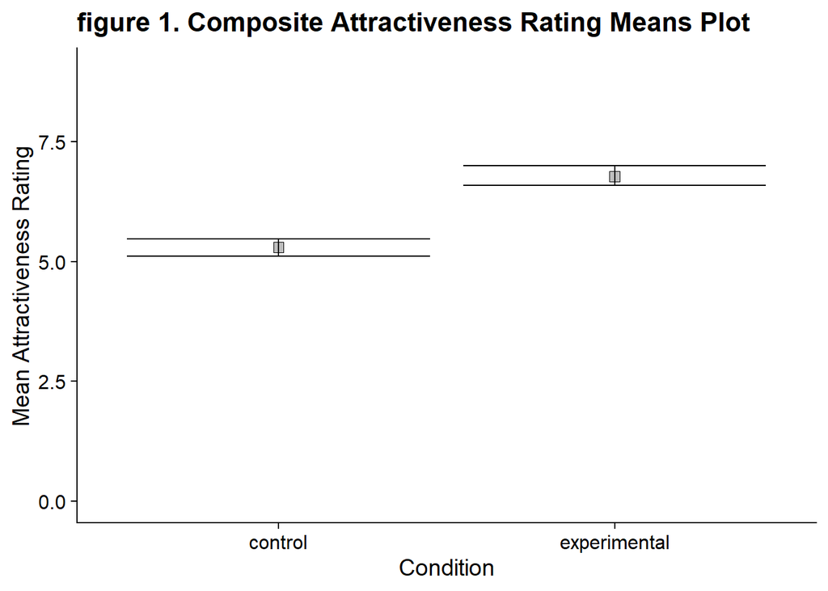

```
##
##  Two Sample t-test
##
## data:  composite_attract_score by condition
## t = -10.861, df = 126, p-value < 0.00000000000000022
## alternative hypothesis: true difference in means is not equal to 0
## 95 percent confidence interval:
##  -1.752523 -1.212325
## sample estimates:
##      mean in group control mean in group experimental
##                   5.293532                   6.775956
```

```
##
## Call:
## lm(formula = composite_attract_score ~ condition, data = .)
##
## Coefficients:
##           (Intercept)  conditionexperimental
##                 5.294                  1.482
```

# **Methods**

## **Participants**

In this experiment there were 150 female participants, 75 in each condition (red frame or white frame). From the total 150 participants, three participants were not included due to incomplete data (NAs) and a further 19 participants had their data removed due to their reported age being under 18. Therefore, over all my study included the data from 128 participants. The participants ages ranged from 18 to 25 with a mean of 20.41 and a standard deviation of 1.89. Condition one constitutes the control condition in which the participants were shown the photograph in the white frame, and condition two was the experimental condition (red frame). Of the 128 sets of data statistically analysed, 67 sets were in the control condition and 61 were from the experimental condition.

*Table 1. Descriptive statistics for age*

| mean_age | sd_age | min_age | max_age |
| --- | --- | --- | --- |
| 20.41 | 1.89 | 18 | 25 |

*Table 2. Descriptive statistics by condition*

| condition | N | % | mean_age |
| --- | --- | --- | --- |
| control | 67 | 52.34 | 20.24 |
| experimental | 61 | 47.66 | 20.59 |

## **Design**

#### *The conceptual hypothesis is*: Does colour influence attractiveness?

#### *The operational hypothesis is*: Women in the red/experimental condition will rate the man in the photograph as more attractive than those in the white/control condition

All participants were shown a black and white, 6x4 inch photograph of a man’s upper torso and head in a white frame. The participants were divided into two groups, the control group were shown the photograph in a white frame, while the experimental group were shown the photograph in a red frame. The frame colour was the predictor/independent variable (factor) in the study. The dependent variable (rating) in the study was the mean attractiveness score given by the female participants for the man in the photograph, this score was based on their responses to three items. The three items were assessed on a 1-9 point scale, a score of one indicated the participant found the man unattractive whereas a score of nine indicated high attraction. The items that the participants were asked to respond to were “How attractive do you think this person is?”, “How pleasant is this person to look at?” and, “If I were to meet the person in this picture face to face, I would think he is attractive.”(Elliot et al, 2010). The three scores were averaged for each participant to find an overall attractiveness rating, the higher the score the more attractive the participant found the man in the photograph. Because both groups in the study underwent different conditions, the design of the study was an independent measures design. Post experiment, the participants were asked to guess the intent of the study. The statistical analysis used for the results of this study was the independent T-Test. The T-Test was a suitable statistical test as we were comparing the means of each condition to see if the difference was statistically significant, the independent T-Test was suitable because we were assuming that the two samples were independent.

# **Results**

Initially, the composite scores were calculated, and the means of each condition summarised into a table.

*Table 3. Composite Attraction Scores*

| condition | N | % | Mean_age | Mean_score |
| --- | --- | --- | --- | --- |
| control | 67 | 52.34 | 20.24 | 5.29 |
| experimental | 61 | 47.66 | 20.59 | 6.78 |

The means of the composite scores displayed in this table show that on average the attractiveness ratings for the photograph when presented in the red frame was (M = 6.78) which is higher than when the photo was presented in a white frame (M = 5.29), this shows a mean differences of (Mdiff = 1.48). A means plot was then created which displayed the means of the composite scores and error bars.

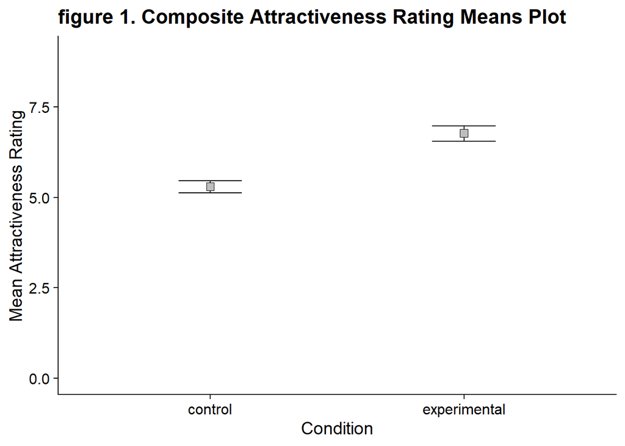

The error bars can provide information about the significance of the difference between the composite scores. The means plot above shows the error bars for the two conditions do not overlap, this indicates significant difference. To analyse the significance of the data further I used a T-test. The results showed a significant difference between the composite score means. The T-value (-10.861) is smaller than the P-value (p < 2.2e-16), this shows that there is a significant difference between the composite scores therefore the null hypothesis should be rejected, and the alternative hypothesis accepted.

```
##
##  Two Sample t-test
##
## data:  composite_attract_score by condition
## t = -10.861, df = 126, p-value < 0.00000000000000022
## alternative hypothesis: true difference in means is not equal to 0
## 95 percent confidence interval:
##  -1.752523 -1.212325
## sample estimates:
##      mean in group control mean in group experimental
##                   5.293532                   6.775956
```

The linear model was also considered in relation to the data collected. The intercept (b0) was 5.294 and the slope (b1) was 1.482. The positive value of b1 suggests that there is a positive correlation between the red frame colour and perceived attractiveness, again suggesting the null hypothesis should be rejected. The linear model equation can be used to predict attractiveness ratings of a participant based on the condition they are in. *attractiveness = b0 + b1(white/red) + error = 5.294 + 1.482(white/red) + error*

```
##
## Call:
## lm(formula = composite_attract_score ~ condition, data = .)
##
## Coefficients:
##           (Intercept)  conditionexperimental
##                 5.294                  1.482
```

# **Discussion**

The results from this study support the experimental hypothesis that “red enhances women’s attraction to men” (Elliot et al, 2010). The study showed that women who were shown the photograph of the man in a red frame rated him to be significantly more attractive then when the photograph was displayed to the participants in the white frame. When looking at the results of the Elliot et al’s (2010) study, it is clear the results are very similar to those above, both showing increased attractiveness ratings for the male in the photograph when the photograph was displayed in conjunction with the colour red as opposed to white. Both sets of results displayed significant difference between the means of the experimental and control conditions when analysed using the T-Test, further supporting the experimental hypothesis. Due to the similar findings of both studies, it would be reasonable to infer that the red effect is real and significant. The red effect is also supported when looking at the connotations of the colour red cross culturally, “Research on color associations indicates that people across cultures link red to love and passion” (Aslam, 2006; Jacobs, Keown, Worthley, & Gyhmn, 1991; Neto, 2002, cited in Elliot et al 2010). However, when looking at one of the studies conducted by Peperkoorn et al (2016), it was found that “the woman in red was not considered to be significantly more sexually attractive than the woman dressed in either black or white” this brings into question the existence of the red affect as the results found in this study contradict those of the studies previously mentioned. This may provide an interesting insight into how the red effect may be influenced by gender.

There are robust aspects of the method that indicate the results of the study should be trusted, and therefore, that the red effect is real. For instance, the participants failure to correctly guess the intent of the study indicates a lack of demand characteristics, suggesting high internal validity as the participants were influenced by the colour without their knowledge. A further way in which the method ensured high internal validity was due to the controlled nature of the lab setting as the procedure was standardised to a high degree. Despite the positive aspects of the controlled lab environment described above, this method of investigation also raises questions in terms of the ecological validity and overall generalisability of the findings. Because of the highly controlled conditions we cannot be sure if the red effect would translate into everyday life. A further issue with the study above is that it only looked at the red effect in regards to female’s attractiveness ratings of the males and not vice versa, for this reason the results of the study lack generalisability across both the sexes, therefore can only support the hypothesis that women find men more attractive in conjunction with the colour red, and not the this effect is present in males perceptions of attractiveness of women. The independent measures design used in the study meant that different groups of women judged the attractiveness of the male in each of the control or experimental condition. This experimental design has positive aspects such as reducing order and fatigue effects. However, it is also a limitation as the two groups of participants may have prior individual differences in preference that could affect their ratings of the man in the photograph. The participants who took part in the studies ranged in age from 18 – 25, this limited age-range of participants decreases the external validity of the findings as it does not address the red effect across all age groups meaning data cannot provide evidence for the red effect in all people, only in the small age range studied. The results from both this study and that of Elliot et al (2010), found support for the existence of red effect. When examining other research such as that of Peperkoorn et al (2016) however, who looked at the effect of the colour red on male’s attractiveness ratings of females, it was found that “higher attractiveness ratings were not given for the woman in red. Instead, a marginally significant white effect on attractiveness emerged.”(Peperkoorn et al,2016). As well as directly contradicting the previously mentioned research it also brings into question the red effects generalisability to the population, specifically when genders are reversed. Peperkoorn et al’s (2016) research indicates that further research would be required in order to fully investigate the red effect as a universal concept. A future study could compare not only female’s attractiveness ratings of males but vice versa and could also investigate the effects of attractiveness ratings of same sex participants to establish if the effect is real across multiple contexts. A future study that may reduce the impact of individual differences and confounding variables on the results, could use a preliminary questionnaire establishing the participants preferences in order to create a typology that would allow the experimental and control groups to be stratified. Another suggestion for further investigation would be to ask the participants to rate attractiveness of the person in the photograph when the colour red is presented in more naturalistic ways. While this study only looks at males in conjunction with the colour red in the form of the frame colour, more natural method might include the person in the photograph wearing a red item of clothing, or against a natural red background to make the findings more ecologically valid. A final suggestion for further research would be to expand the age range of participants included to establish whether the red effect is real beyond the limited scope of this study, thus making it more generalisable. Although the results of this study generally concur with that of Elliot et al. (2010), it is clear that neither study are able to conclusively prove the existence of the red effect. When looking at my own data, despite the significant differences of findings between the conditions, the limitations presented by the design of the study itself, mean that these findings alone are not sufficient to say for absolute certainty that the effect exists. Additionally, when looking at the findings of other research into the existence of the red effect, there are recurring contradictions. Similarly, it appears that studies into the red effect fail to incorporate an inclusive participant pool and create an ecologically valid range of contexts in which to test participants.

# **References**

Peperkoorn, L., Roberts, S., & Pollet, T. (2016). Revisiting the Red Effect on Attractiveness and Sexual Receptivity. Evolutionary Psychology, 14(4), 147470491667384. doi: 10.1177/1474704916673841

Francis, G. (2013). Publication bias in “Red, rank, and romance in women viewing men,” by Elliot et al. (2010). Journal Of Experimental Psychology: General, 142(1), 292-296. doi: 10.1037/a0027923